# Data Visualization

### Importing Libraries

```python
import numpy as np
import pandas as pd
import matplotlib.pyplot as plt
import seaborn as sns
%matplotlib inline
import plotly.express as px
import datetime
import plotly.graph_objects as go
from ipywidgets import interactive, HBox, VBox, widgets, interact, Label
sns.set_style("darkgrid")
```

### Data

```python
#loading the data
data = pd.read_csv("data/suicide.csv")
data.head()
```

|  | country | year | sex | age | suicides_no | population | suicides/100k pop | country-year | HDI for year | gdp_for_year ($) | gdp_per_capita ($) | generation |
| --- | --- | --- | --- | --- | --- | --- | --- | --- | --- | --- | --- | --- |
| 0 | Albania | 1987 | male | 15-24 years | 21 | 312900 | 6.71 | Albania1987 | NaN | 2,156,624,900 | 796 | Generation X |
| 1 | Albania | 1987 | male | 35-54 years | 16 | 308000 | 5.19 | Albania1987 | NaN | 2,156,624,900 | 796 | Silent |
| 2 | Albania | 1987 | female | 15-24 years | 14 | 289700 | 4.83 | Albania1987 | NaN | 2,156,624,900 | 796 | Generation X |
| 3 | Albania | 1987 | male | 75+ years | 1 | 21800 | 4.59 | Albania1987 | NaN | 2,156,624,900 | 796 | G.I. Generation |
| 4 | Albania | 1987 | male | 25-34 years | 9 | 274300 | 3.28 | Albania1987 | NaN | 2,156,624,900 | 796 | Boomers |

```python
# ISO country codes
iso_code = pd.read_csv("data/wikipedia-iso-country-codes.csv")
iso_code.head()
```

|  | English short name lower case | Alpha-2 code | Alpha-3 code | Numeric code | ISO 3166-2 |
| --- | --- | --- | --- | --- | --- |
| 0 | Afghanistan | AF | AFG | 4 | ISO 3166-2:AF |
| 1 | Åland Islands | AX | ALA | 248 | ISO 3166-2:AX |
| 2 | Albania | AL | ALB | 8 | ISO 3166-2:AL |
| 3 | Algeria | DZ | DZA | 12 | ISO 3166-2:DZ |
| 4 | American Samoa | AS | ASM | 16 | ISO 3166-2:AS |

```python
#Continents file
continent =pd.read_csv("data/countryContinent.csv", encoding='iso-8859-1')
continent.head()
```

|  | country | code_2 | code_3 | country_code | iso_3166_2 | continent | sub_region | region_code | sub_region_code |
| --- | --- | --- | --- | --- | --- | --- | --- | --- | --- |
| 0 | Afghanistan | AF | AFG | 4 | ISO 3166-2:AF | Asia | Southern Asia | 142.0 | 34.0 |
| 1 | Åland Islands | AX | ALA | 248 | ISO 3166-2:AX | Europe | Northern Europe | 150.0 | 154.0 |
| 2 | Albania | AL | ALB | 8 | ISO 3166-2:AL | Europe | Southern Europe | 150.0 | 39.0 |
| 3 | Algeria | DZ | DZA | 12 | ISO 3166-2:DZ | Africa | Northern Africa | 2.0 | 15.0 |
| 4 | American Samoa | AS | ASM | 16 | ISO 3166-2:AS | Oceania | Polynesia | 9.0 | 61.0 |

```python
#renaming the column to it's right name so we can later merge the dataframes.
iso_code = iso_code.rename(columns = {'English short name lower case':"country"})
continent = continent.rename(columns = {'code_3':"Alpha-3 code"})
```

We will merge the suicide data with `iso-country-codes` and `countryContinent` since the data is related based on some common information and we need all the data for visualization.

```python
#merge 3 dataframes
data = pd.merge(data,iso_code,on='country',how='left')
data = pd.merge(data,continent,on='Alpha-3 code',how='left')
del data['country_y']
```

GDP per capita = GDP / Population. We will use this formulae to find GDP of each country for each year from the available data.

```python
data['gdp'] = data['gdp_per_capita ($)']*data['population']
```

```python
data['year'].value_counts()
```

```
2009    1068
2001    1056
2010    1056
2007    1032
2011    1032
2002    1032
2003    1032
2000    1032
2006    1020
2008    1020
2005    1008
2004    1008
1999     996
2012     972
2013     960
```

[output cut: 18 more lines]

```python
data['continent'].value_counts()
```

```
Europe      11094
Americas     8542
Asia         4982
Oceania       972
Africa        838
Name: continent, dtype: int64
```

```python
#group data by continents
continent_data = data.groupby(['continent','sex','year']).sum().reset_index()
#since we are adding up the population and gdp so we need to calculate gdp per capita again.
continent_data['gdp_per_capita ($)'] = continent_data['gdp']/continent_data['population']
```

```python
continent_data.head()
```

|  | continent | sex | year | suicides_no | population | suicides/100k pop | HDI for year | gdp_per_capita ($) | Numeric code | country_code | region_code | sub_region_code | gdp |
| --- | --- | --- | --- | --- | --- | --- | --- | --- | --- | --- | --- | --- | --- |
| 0 | Africa | female | 1985 | 37 | 470300 | 74.85 | 3.45 | 1328.206889 | 7020.0 | 7020.0 | 24.0 | 168.0 | 624655700 |
| 1 | Africa | female | 1986 | 8 | 478100 | 8.00 | 0.00 | 1755.988496 | 7020.0 | 7020.0 | 24.0 | 168.0 | 839538100 |
| 2 | Africa | female | 1987 | 53 | 487000 | 76.32 | 0.00 | 2205.994251 | 7020.0 | 7020.0 | 24.0 | 168.0 | 1074319200 |
| 3 | Africa | female | 1988 | 56 | 464900 | 59.45 | 0.00 | 2317.000000 | 2880.0 | 2880.0 | 12.0 | 84.0 | 1077173300 |
| 4 | Africa | female | 1989 | 37 | 470000 | 59.33 | 0.00 | 2349.000000 | 2880.0 | 2880.0 | 12.0 | 84.0 | 1104030000 |

```python
#calculating suicides/100k pop continent wise.
continent_data['suicides/100k pop'] = continent_data['suicides_no']*1000/continent_data['population']
continent_data.head()
```

|  | continent | sex | year | suicides_no | population | suicides/100k pop | HDI for year | gdp_per_capita ($) | Numeric code | country_code | region_code | sub_region_code | gdp |
| --- | --- | --- | --- | --- | --- | --- | --- | --- | --- | --- | --- | --- | --- |
| 0 | Africa | female | 1985 | 37 | 470300 | 0.078673 | 3.45 | 1328.206889 | 7020.0 | 7020.0 | 24.0 | 168.0 | 624655700 |
| 1 | Africa | female | 1986 | 8 | 478100 | 0.016733 | 0.00 | 1755.988496 | 7020.0 | 7020.0 | 24.0 | 168.0 | 839538100 |
| 2 | Africa | female | 1987 | 53 | 487000 | 0.108830 | 0.00 | 2205.994251 | 7020.0 | 7020.0 | 24.0 | 168.0 | 1074319200 |
| 3 | Africa | female | 1988 | 56 | 464900 | 0.120456 | 0.00 | 2317.000000 | 2880.0 | 2880.0 | 12.0 | 84.0 | 1077173300 |
| 4 | Africa | female | 1989 | 37 | 470000 | 0.078723 | 0.00 | 2349.000000 | 2880.0 | 2880.0 | 12.0 | 84.0 | 1104030000 |

We have the most data available for 2009 so let's see the trend for this year

```python
#subset data
suicides_2009 = continent_data[continent_data['year']==2009]
```

```
Text(0.5,1,'GDP Per Capita for Suicides/100k Population (2009)')
```

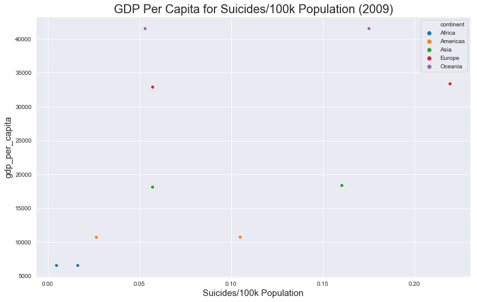

```python
plt.figure(figsize=(13,8))
sns.scatterplot(x="suicides/100k pop", y="gdp_per_capita ($)", hue="continent", data=suicides_2009)
plt.xlabel('Suicides/100k Population',fontsize =15)
plt.ylabel('gdp_per_capita',fontsize =15)
plt.title('GDP Per Capita for Suicides/100k Population (2009)', fontsize= 20)
```

It seems like a pretty plot with all the colors and circles right? You might have noticed that why are there 2 bubbles with the same color? Well if you look back at the data then we grouped it by the sex column hence one circle is for females and 1 is for males.  
What information can you takeaway from this plot?

- There is a difference between gdp_per_capita for suicides/100k population between continents and between males and females, right?
- To compare the values we will have to navigate between the x-axis and y-axis back and forth right? What if there was some way to display that information in the plot?

```python
px.scatter(suicides_2009,x = 'suicides/100k pop', y = 'gdp_per_capita ($)',color='continent',size ='suicides/100k pop', title = 'GDP Per Capita for Suicides/100k Population (2009)')
```

[interactive chart not shown]

- Now the information is presented in a much better way. It's easier to read. Won't take that long that a small bubble represents a smaller value while a larger bubble represents a bigger value.
- I can also hover over the bubbles to see the exact values rather then trying to approximate from the axis.
- There is still something confusing about the plot. What if i want to instantly compare the values using the sex variable for the continents? There is no way to know using the plot.
- To cater to this problem, we can use different symbols for males and females.

```python
px.scatter(suicides_2009,x = 'suicides/100k pop', y = 'gdp_per_capita ($)', size = 'suicides/100k pop', color='continent',
           symbol='sex',title = 'GDP Per Capita for Suicides/100k Population (2009)'
        )
```

[interactive chart not shown]

Now I can use my legend to distinguish between males and females. Take a moment to appreciate that how a little detail can add so much context to the plot!

- There is a significant difference between the suicide rates of Male vs Females.
- Asia has a lower GDP per capita and a lower suicide rate than Europe. Africa has the lowest GDP and the lowest suicide rate
- The sucide rate for european males was the highest for the year 2009.

Now let's convert our plot into time frames. For this, I will use all my data.

```python
px.scatter(continent_data,x = 'suicides/100k pop', y = 'gdp_per_capita ($)',color='continent',
               size='suicides/100k pop',symbol='sex',animation_frame='year', animation_group='continent',range_x = [0,0.5],
              range_y = [0,80000])
```

[interactive chart not shown]

- Despite having a high GDP, Oceania is still susceptible to high suicide rates.
- Overall Africa has the lowest suicide rates.
- With each little information we added into the plot, we can build so many hypotheses out of these and test them as well!

Let's have a look at the european males since the suicide rate among them was the highest

```python
#regroup the data again by age.
europe_data = data[data['continent'] =='Europe']
europe_data  = europe_data.groupby(['age','sex','year']).sum().reset_index()
europe_data['suicides/100k pop'] = europe_data['suicides_no']*1000/europe_data['population']
```

```python
px.bar(europe_data ,x='age',y='suicides/100k pop',facet_col='sex',animation_frame='year',
       animation_group='age',
       category_orders={'age':['5-14 years', '15-24 years', '25-34 years', '35-54 years',
       '55-74 years', '75+ years']})
```

[interactive chart not shown]

Overall, suicide rate of 75+ males was very high. That might have increased the overall suicide rate for males.

Now we want to see whether suicide rates increase or decrease for a country using a map.That is why we got the ISO-codes for the country in the data.

```python
plot = data.groupby(['year','country_x','Alpha-3 code']).sum().reset_index()
# plot["suicides/100k pop"] = plot["suicides_no"]*1000/plot["population"]
px.choropleth(plot, locations="Alpha-3 code", color="suicides/100k pop", hover_name="country_x", animation_frame="year",
             color_continuous_scale=px.colors.sequential.Viridis)
```

[interactive chart not shown]